# 임금 예측

목적 : 노동자들의 특성에 대한 선형 결합을 사용하여 노동자들의 임금을 예측하고 평균 제곱 오차 (MSE)와 조정된 MSE 와 r-squared 그리고 표본에서 벗어난 (out-of-sample) MSE 와 r-squared를 사용하여 예측 성능을 평가해보는 것임.

결과 변수 Y는 시간당 임금이며, X는 성별, 경험, 교육, 지리적 정보에 관련된 다양한 특성 지표들이다.

# Dataset

데이터셋은 다음 변수들을 포함한다.

1. wage : weekly wage
2. female : female dummy
3. cg : college Graduate Dummy
4. sc : some college dummy
5. hsg : High School graduate dummy
6. mw : mid-west dummy
7. so : south dummy
8. we : west dummy
9. ne : northeast dummy
10. exp1 : experience(year)
11. exp2 : experience squared (taken as experience squared/100)
12. exp3 : experience cubed (taken as experience cubed/1000)

## **Importing the necessary libraries and overview of the dataset**

```python
import numpy as np
import pandas as pd
import matplotlib.pyplot as plt
import seaborn as sns

# to ignore warnings
import warnings
warnings.filterwarnings("ignore")

# pandas 지수표현 없애기
pd.options.display.float_format = '{:.5f}'.format
```

### **Loading the data**

```python
df = pd.read_csv("data-wages_prediction/01_predicting_wages.csv")
```

```python
df.head()
```

|  | female | cg | sc | hsg | mw | so | we | ne | exp1 | exp2 | exp3 | wage |
| --- | --- | --- | --- | --- | --- | --- | --- | --- | --- | --- | --- | --- |
| 0 | 0 | 0 | 0 | 1 | 0 | 0 | 0 | 1 | 33.00000 | 10.89000 | 35.93700 | 11.65909 |
| 1 | 0 | 1 | 0 | 0 | 0 | 0 | 0 | 1 | 27.00000 | 7.29000 | 19.68300 | 12.82500 |
| 2 | 0 | 0 | 1 | 0 | 0 | 0 | 0 | 1 | 13.00000 | 1.69000 | 2.19700 | 5.77703 |
| 3 | 0 | 1 | 0 | 0 | 0 | 0 | 0 | 1 | 2.00000 | 0.04000 | 0.00800 | 12.46875 |
| 4 | 1 | 1 | 0 | 0 | 0 | 0 | 0 | 1 | 15.00000 | 2.25000 | 3.37500 | 18.52500 |

### **데이터 정보 확인**

```python
df.info()
```

```
<class 'pandas.core.frame.DataFrame'>
RangeIndex: 3835 entries, 0 to 3834
Data columns (total 12 columns):
 #   Column  Non-Null Count  Dtype
---  ------  --------------  -----
 0   female  3835 non-null   int64
 1   cg      3835 non-null   int64
 2   sc      3835 non-null   int64
 3   hsg     3835 non-null   int64
 4   mw      3835 non-null   int64
 5   so      3835 non-null   int64
 6   we      3835 non-null   int64
 7   ne      3835 non-null   int64
 8   exp1    3835 non-null   float64
 9   exp2    3835 non-null   float64
 10  exp3    3835 non-null   float64
 11  wage    3835 non-null   float64
dtypes: float64(4), int64(8)
memory usage: 359.7 KB
```

**Observations**:

- 3835개의 관찰 데이터값이 있고, 12개의 다른 변수들이 있음
- 데이터셋에 결측값이 없음
- 모든 더미 변수 (cg,sc,hsg, etc) 는 int 데이터 타입이고, 이항 변수로 0 과 1의 값을 가지고 있음

# 단변량 분석 (**Univariate Analysis**)

## 데이터셋의 통계 요약 정보를 확인해보자.

```python
df.describe().T
```

|  | count | mean | std | min | 25% | 50% | 75% | max |
| --- | --- | --- | --- | --- | --- | --- | --- | --- |
| female | 3835.00000 | 0.41799 | 0.49329 | 0.00000 | 0.00000 | 0.00000 | 1.00000 | 1.00000 |
| cg | 3835.00000 | 0.37627 | 0.48451 | 0.00000 | 0.00000 | 0.00000 | 1.00000 | 1.00000 |
| sc | 3835.00000 | 0.32386 | 0.46801 | 0.00000 | 0.00000 | 0.00000 | 1.00000 | 1.00000 |
| hsg | 3835.00000 | 0.29987 | 0.45826 | 0.00000 | 0.00000 | 0.00000 | 1.00000 | 1.00000 |
| mw | 3835.00000 | 0.28761 | 0.45271 | 0.00000 | 0.00000 | 0.00000 | 1.00000 | 1.00000 |
| so | 3835.00000 | 0.24355 | 0.42928 | 0.00000 | 0.00000 | 0.00000 | 0.00000 | 1.00000 |
| we | 3835.00000 | 0.21173 | 0.40859 | 0.00000 | 0.00000 | 0.00000 | 0.00000 | 1.00000 |
| ne | 3835.00000 | 0.25711 | 0.43710 | 0.00000 | 0.00000 | 0.00000 | 1.00000 | 1.00000 |
| exp1 | 3835.00000 | 13.35319 | 8.63935 | 2.00000 | 6.00000 | 11.00000 | 19.50000 | 35.00000 |
| exp2 | 3835.00000 | 2.52927 | 2.91055 | 0.04000 | 0.36000 | 1.21000 | 3.80250 | 12.25000 |
| exp3 | 3835.00000 | 5.81210 | 9.03321 | 0.00800 | 0.21600 | 1.33100 | 7.41488 | 42.87500 |
| wage | 3835.00000 | 15.53336 | 13.51817 | 0.00428 | 9.61875 | 13.02857 | 17.81250 | 348.33302 |

**Observations:**

- 평균 임금은 대략 시간당 15달러 이고, 최대값은 348달러 로 매우 높다.
- 42% 가 여성 노동자다.
- 평균 경력 년수는 13년이고, 최소 경력년수는 2년 최대 경력년수는 35년이다. 이는 다양한 경력 그룹으로 부터 추출된 다양화된 데이터임을 암시한다.
- 데이터의 38%가 대학 졸업자들이다.
- 32%가 대학 재학중 (some college)이고, 30% 가 고등학교 졸업생이다.
- 주의 주요 지리적 지역에 걸친 노동자들의 지리적 분포도 볼 수 있으며, 22-28% 사이에서는 거의 동일한 것으로 보이며, 이는 데이터가 여러 지역에서 균일한 방식으로 수집되고 있음을 다시 보여준다.

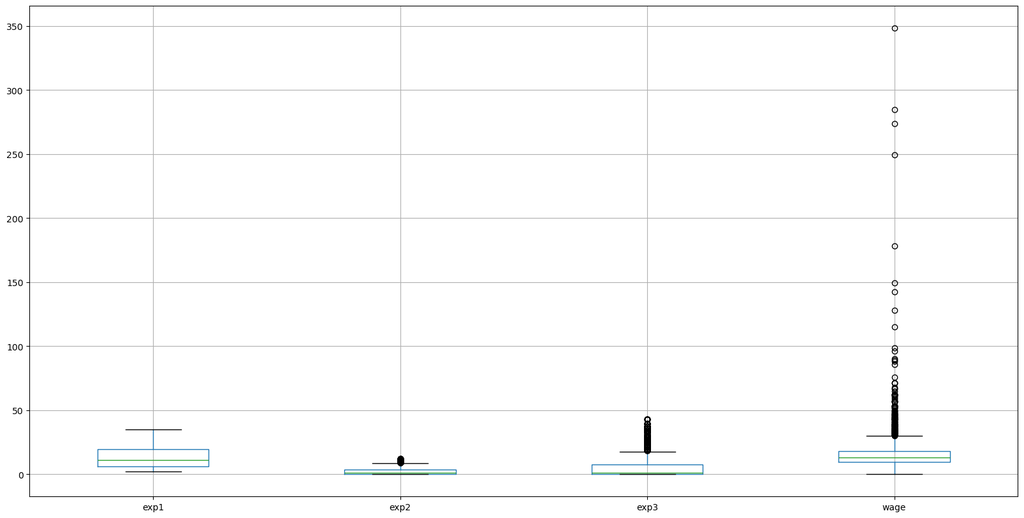

```python
df[['exp1','exp2','exp3','wage']].boxplot(figsize=(20,10))
plt.show()
```

- wage 변수에 대해서 아웃라이어가 있음을 확인할 수 있으며, 몇몇 사람들이 다른 사람들 보다 더 높은 수익을 얻는다는 점은 그럴사 하다.

# 이변량 분석 (**Bivariate Analysis**)

## 경력 년수와 임금간의 관계를 첫번째로 살펴보자

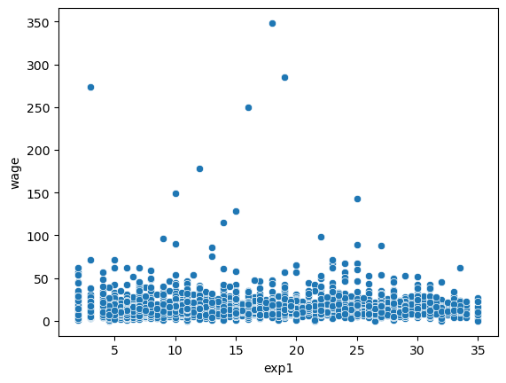

```python
sns.scatterplot(data = df, x = 'exp1',y = 'wage')
plt.show()
```

- 위에서 볼 수 있듯, 경험과 임금간의 상당한 관계까 없음을 알 수있다. 일반적인 가정을 해보면 높은 경력수준을 가진 사람들이 높은 임금을 받는 것은 여기서는 아닌 것처럼 보인다.

## dumpy 컬럼의 리스트를 만들어서 임금과의 관계를 확인해보자

```python
cols = df.select_dtypes('int').columns.to_list()
cols
```

```
['female', 'cg', 'sc', 'hsg', 'mw', 'so', 'we', 'ne']
```

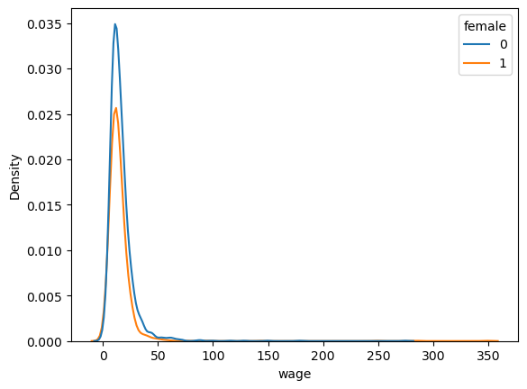

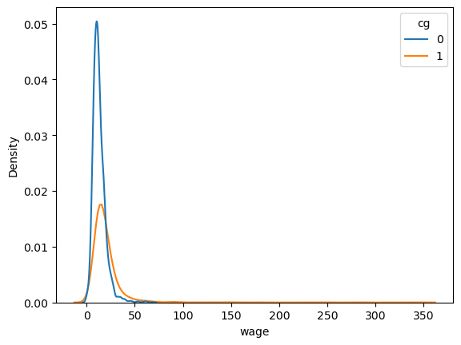

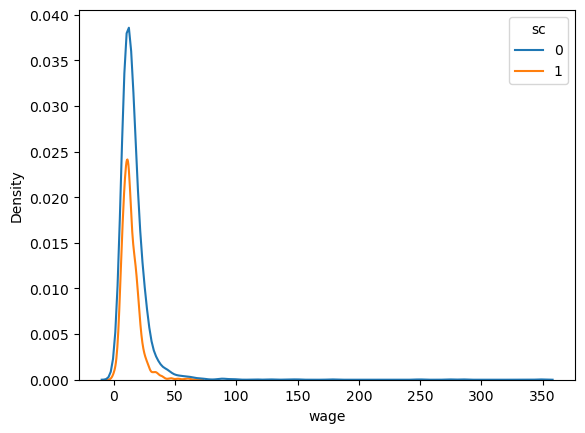

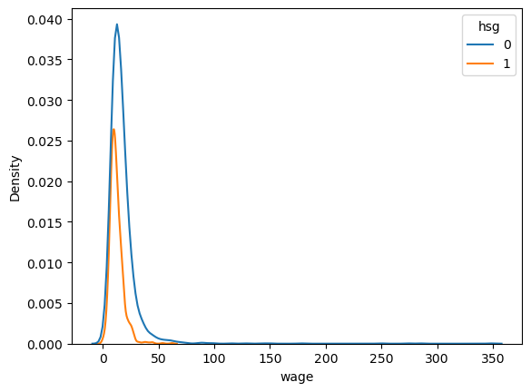

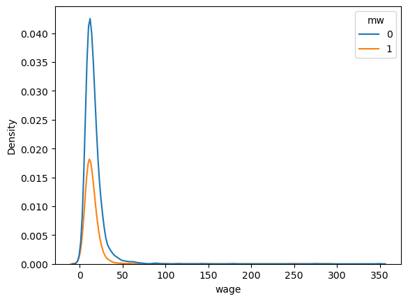

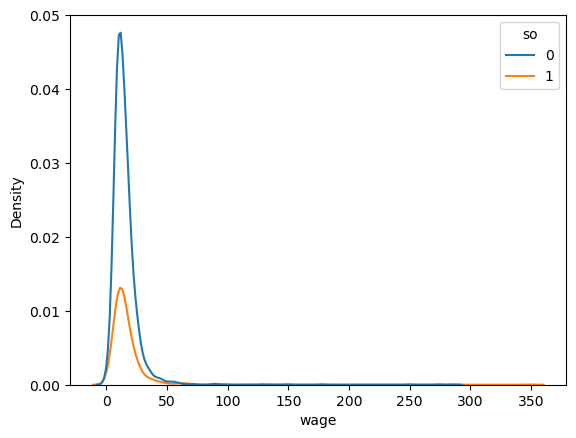

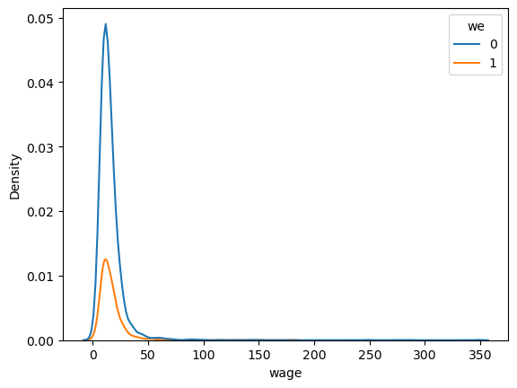

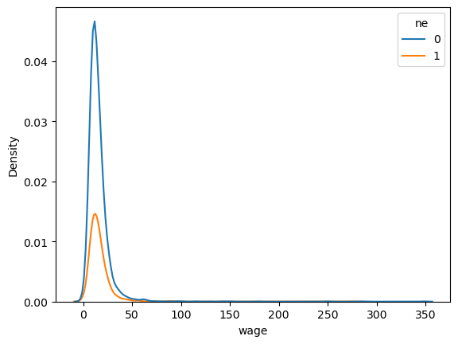

```python
for col in cols:
    sns.kdeplot(data = df, x = 'wage', hue = df[col])
    plt.show()
```

- 이들 그림에서는 여성, 교육수준, 지리적 지역(주황색, 청색)의 임금 분포가 크게 다르지 않음을 볼 수 있다.

### Basic Model

- X 는 여성 여부(female indicator) (D) 와 다른 통제 변수 (W) 로 구성되며, 다른 통제 변수에는 constant, experience, experience squared, experience cubed, education indicators, and regional indicators 로 구성된다
- X는 p = 9 인 회귀 변수을 포함한다. (female, cg, sc, hsg, mw, so, we, ne, exp (9개 설명변수)

```python
####################  Linear and Quadratic specifications ##############################

from sklearn.linear_model import LinearRegression
from sklearn import metrics

Y = df['wage'] # target variable
X = df[['female', 'sc', 'cg', 'mw', 'so', 'we', 'exp1', 'exp2', 'exp3']] # regressors

# defining the model
model = LinearRegression()
# fit the Linear regression to the regressors and target variable.
results = model.fit(X,Y) # train the model

print("Intercept", results.intercept_) # beta_0
```

```
Intercept 4.915401521241467
```

```python
# coeeficients of other regressors

pd.DataFrame(results.coef_.reshape(1,-1), columns = X.columns)
```

|  | female | sc | cg | mw | so | we | exp1 | exp2 | exp3 |
| --- | --- | --- | --- | --- | --- | --- | --- | --- | --- |
| 0 | -1.82640 | 2.48652 | 9.87081 | -1.21424 | 0.40460 | -0.25080 | 1.09646 | -4.01339 | 0.46034 |

**Observations:**

- 대학 졸업자들이 더높은 임금을 받는것을 증명하든, cg 변수가 높은 계수를 가지고 있는것을 확인할 수 있습니다.
- Exp2 는 음의 상관계수를 가지는데, 이것은 exp2 일 수록 임금이 낮아지는 것을 의미합니다.
- female 요인의 계수는 음의 상관계수를 가지는데, 여성일수록 더 낮은 임금을 받는 다는 것을 의미합니다.

```python
# compute MSE and R^2
y_pred = results.predict(X)
print("R-squared", metrics.r2_score(Y, y_pred)) # R-squared
n = X.shape[0]
k = X.shape[1]
MSE_adj2 = ( n / (n - (k-1)) * np.mean(np.square(Y-y_pred)))
print("MSE adj:", MSE_adj2)
```

```
R-squared 0.0954880031243256
MSE adj: 165.59357036973162
```

- r-sqaured가 매우 낮은 것으로 보아 모델 성능이 매우 좋지 않은 것으로 보인다.

```python
rsquared = metrics.r2_score(Y, y_pred)
adj_rsquared = 1 - ((1- rsquared) * (n-1) / (n-k-1))
print("Adj Rsquared:", adj_rsquared) # adjusted r-squared
```

```
Adj Rsquared: 0.09335973960226518
```

## Flexible model

- X는 기본 모델에서 W의 모든 요소와 이들의 양방향 상호작용을 포함하는 W뿐만 아니라 D로도 구성된다.
- 양방향 상호작용이 의미하는 바는 두 변수들이 서로서로 배수이므로, 모델에서 2변수의 결합된 상호작용 효과를 포착할 수 있다.
- 상호작용 features를 만든 후에 X 는 p = 37 개의 회귀변수들을 포함한다.

```python
# Linear regression: Quadratic specification

from sklearn.preprocessing import PolynomialFeatures

X.drop('female', axis = 1, inplace = True)
poly = PolynomialFeatures(interaction_only = True, include_bias = True)
X_poly = poly.fit_transform(X) # creating polynomial features with degree = 2 (Quadratic)
```

```python
X_poly.shape
```

```
(3835, 37)
```

```python
X_poly = pd.DataFrame(X_poly, columns = poly.get_feature_names_out(X.columns))
```

```python
X_poly['female'] = df['female']
X['female'] = df['female']

# train the model
results = model.fit(X_poly, Y)

# beta_0
print("Intercept", results.intercept_)
```

```
Intercept 16.552407194268568
```

```python
pd.DataFrame(results.coef_.reshape(1,-1), columns = X_poly.columns).T.sort_values(by=0, ascending =False) # printing the co-efficients in a tabular format
```

|  | 0 |
| --- | --- |
| exp2 | 12.52185 |
| cg | 2.24049 |
| cg so | 1.70405 |
| mw exp1 | 1.10761 |
| mw exp3 | 0.90626 |
| sc exp1 | 0.83908 |
| we exp3 | 0.80500 |
| cg exp1 | 0.78588 |
| sc exp3 | 0.63303 |
| we exp1 | 0.47192 |
| so exp1 | 0.39470 |
| exp1 exp3 | 0.08721 |
| 1 | 0.00000 |
| mw we | 0.00000 |
| so we | -0.00000 |
| mw so | -0.00000 |
| sc cg | -0.00000 |
| so exp3 | -0.03516 |
| exp3 | -0.04839 |
| cg exp2 | -0.04897 |
| exp2 exp3 | -0.05798 |
| sc we | -0.10465 |
| exp1 exp2 | -0.48387 |
| cg exp3 | -0.59503 |
| sc so | -0.65126 |
| sc mw | -0.72256 |
| cg mw | -0.76091 |
| we | -0.80539 |
| so exp2 | -0.89137 |
| exp1 | -1.32146 |
| cg we | -1.49476 |
| female | -1.88001 |
| sc | -2.38653 |
| so | -2.91439 |
| we exp2 | -3.91883 |
| sc exp2 | -4.06085 |
| mw | -5.51940 |
| mw exp2 | -6.05268 |

**Observations:**

```python
# compute MSE 와 R^2 계산
# compute MSE and R^2
y_pred = results.predict(X_poly)
print("R-squared", metrics.r2_score(Y, y_pred)) # R-squared
n = X_poly.shape[0]
k = X_poly.shape[1]
MSE_adj2 = ( n / (n - (k-1)) * np.mean(np.square(Y-y_pred)))
print("MSE adj:", MSE_adj2)
```

```
R-squared 0.10397282164398391
MSE adj: 165.2927569381851
```

- 모델 성능이 기본 모델의 r-squared 와 비교했을 때 약간 향상했으나, 매우 적은양입니다.
- 전체 설명변수는 33개를 고려했고, cgsc, sowe, mwwe, mwso 는 거의 0입니다. 이는 모델에 거의 어떤 기여도 하지 않는 것을 보입니다.

```python
rsquared = metrics.r2_score(Y, y_pred)
adj_rsquared = 1 - ((1- rsquared) * (n-1) / (n-k-1))
print("Adj Rsquared:", adj_rsquared) # adjusted r-squared
```

```
Adj Rsquared: 0.09500310805664758
```

- 우리는 basic, flexible 두가지 예측 모델을 고려해보았습니다.
- 베이직 모델에서 설명 변수는 여성 여부 D와 다른 설명변수, constant, experience, experience squared, experience cubed, education and regional indicators 의 W를 포함했습니다. 기본 모델은 9개의 설명변수를 가집니다 .

여기서 p/n이 상당히 작다는 점을 고려하면 표본 선형 회귀는 모집단 선형 회귀를 상당히 잘 근사화해야 한다.

```python
p = 9
n = X.shape[0]
p/n
```

```
0.002346805736636245
```

[output not shown]

basic 모델과 flexible 모델의 성능이 거의 동일하며, felxible 모델이 조금 더 낫다는 결론을 내릴 수 있다. (R2가 살짝 더 높고, MSE가 살짝 더 낮다)

### **Basic Model on splitted data**

```python
####################  Linear and Quadratic specifications with Sample Splitting ##############################

from sklearn.model_selection import train_test_split #using this we split the data into train and test in python.

#Split using the function train_test_split
# X_train, X_test, Y_train, Y_test = train_test_split( X, Y, test_size = 0.5, random_state = 101) # random split

#split without the function train_test_split
ind = int(X.shape[0] * 0.5 ) + 1 # test size= 0.5
X_train = X.iloc[:ind, :]
X_test = X.iloc[ind:, :]
Y_train = Y.iloc[:ind]
Y_test = Y.iloc[ind:]

results = model.fit(X_train, Y_train)
print("intercept", results.intercept_)
```

```
intercept 4.184615914173724
```

```python
pd.DataFrame(results.coef_.reshape(1,-1), columns = X.columns)
```

|  | sc | cg | mw | so | we | exp1 | exp2 | exp3 | female |
| --- | --- | --- | --- | --- | --- | --- | --- | --- | --- |
| 0 | 2.38791 | 10.00758 | -0.93945 | 0.00000 | -0.00000 | 1.24133 | -4.76748 | 0.56617 | -1.65474 |

```python
y_pred = results.predict(X_test)
print("R-squared", metrics.r2_score(Y_test, y_pred)) # R-squared
print("MSE", metrics.mean_squared_error(Y_test, y_pred)) # MSE
```

```
R-squared 0.10272836637029858
MSE 154.58369290508847
```

### **Flexible model on splitted data**

```python
####################  Linear and Quadratic specifications with Sample Splitting ##############################

from sklearn.model_selection import train_test_split #using this we split the data into train and test in python.

#Split using the function train_test_split
# X_train, X_test, Y_train, Y_test = train_test_split( X, Y, test_size = 0.5, random_state = 101) # random split

#split without the function train_test_split
ind = int(X_poly.shape[0] * 0.5 ) + 1 # test size= 0.5
X_train = X_poly.iloc[:ind, :]
X_test = X_poly.iloc[ind:, :]
Y_train = Y.iloc[:ind]
Y_test = Y.iloc[ind:]

results = model.fit(X_train, Y_train)
print("intercept", results.intercept_)
```

```
intercept 12.364122069222963
```

```python
pd.DataFrame(results.coef_.reshape(1,-1),columns=X_poly.columns).T
```

|  | 0 |
| --- | --- |
| 1 | 0.00000 |
| sc | 2.33398 |
| cg | 6.48286 |
| mw | -6.64347 |
| so | 0.00000 |
| we | 0.00000 |
| exp1 | -0.91369 |
| exp2 | 16.08340 |
| exp3 | -0.10404 |
| sc cg | 0.00000 |
| sc mw | -0.99051 |
| sc so | 0.00000 |
| sc we | -0.00000 |
| sc exp1 | 0.10770 |
| sc exp2 | -0.84815 |
| sc exp3 | 0.19291 |
| cg mw | 0.01086 |
| cg so | 0.00000 |
| cg we | -0.00000 |
| cg exp1 | 0.21807 |
| cg exp2 | 2.53090 |
| cg exp3 | -1.08261 |
| mw so | 0.00000 |
| mw we | 0.00000 |
| mw exp1 | 1.34946 |
| mw exp2 | -7.15802 |
| mw exp3 | 1.05393 |
| so we | 0.00000 |
| so exp1 | 0.00000 |
| so exp2 | 0.00000 |
| so exp3 | 0.00000 |
| we exp1 | 0.00000 |
| we exp2 | 0.00000 |
| we exp3 | 0.00000 |
| exp1 exp2 | -1.04036 |
| exp1 exp3 | 0.31421 |
| exp2 exp3 | -0.35195 |
| female | -1.75173 |

```python
y_pred = results.predict(X_test)
print("R-squared",metrics.r2_score(Y_test,y_pred))
print("MSE",metrics.mean_squared_error(Y_test,y_pred))
```

```
R-squared 0.10460461287645839
MSE 154.2604495272173
```

### **Conclusion and recommendations:**

|  | p | R-squared_test | MSE_test |
| --- | --- | --- | --- |
| basic reg | 9 | 0.1027 | 154.584 |
| flexi reg | 33 | 0.1046 | 154.260 |

# 성별 임금 차이

## 같은 직무 관련 특성을 가진 남성과 여성 사이의 예측 임금에 어떤 차이가 있을까요?

```python
df.groupby(['female']).mean().T
```

| female | 0 | 1 |
| --- | --- | --- |
| cg | 0.35484 | 0.40611 |
| sc | 0.30197 | 0.35434 |
| hsg | 0.34319 | 0.23955 |
| mw | 0.28495 | 0.29133 |
| so | 0.23522 | 0.25515 |
| we | 0.22133 | 0.19838 |
| ne | 0.25851 | 0.25515 |
| exp1 | 13.58020 | 13.03712 |
| exp2 | 2.58659 | 2.44945 |
| exp3 | 5.96494 | 5.59930 |
| wage | 16.11746 | 14.72006 |

**Observations**

- 먼저 학력이 고등학교, 일부 단과대학 또는 단과대학에 해당하는 미혼남성과 미혼여성의 하위표본에 대한 위와 같은 기술통계를 살펴보았다.
- 남성의 시간당 평균임금은 16달러이고, 여성의 시간당 평균임금은 15달러였다. 따라서 같은 직무 관련 특성을 통제 하지 않으면 차이는 1정도 난다.
- 만약 이 특성을 좀더 살펴본다면, 우리는 평균적으로 남자들이 더 많은 경험을 가지고 있지만, 여자들은 대학 학위나 약간의 대학 교육을 가지고 있을 가능성이 더 높다는 것을 안다.
- 두 남성과 여성의 지리학적 분포는 거의 동일하다.

### **Basic Model**

```python
####################  Linear and Quadratic specifications ##############################

# Wage linear regression
import statsmodels.api as sm
Y = df['wage'] # target variable
X = df[['female' , 'sc', 'cg', 'mw' , 'so' , 'we' , 'exp1' , 'exp2' , 'exp3']] #regressors
X = sm.add_constant(X) # adding constant for intercept
model = sm.OLS(Y, X)
results = model.fit() # train the model
print(results.summary()) # summary of the model
```

```
                            OLS Regression Results
==============================================================================
Dep. Variable:                   wage   R-squared:                       0.095
Model:                            OLS   Adj. R-squared:                  0.093
Method:                 Least Squares   F-statistic:                     44.87
Date:                Wed, 07 Aug 2024   Prob (F-statistic):           3.17e-77
Time:                        16:28:59   Log-Likelihood:                -15235.
No. Observations:                3835   AIC:                         3.049e+04
Df Residuals:                    3825   BIC:                         3.055e+04
Df Model:                           9
Covariance Type:            nonrobust
==============================================================================
                 coef    std err          t      P>|t|      [0.025      0.975]
------------------------------------------------------------------------------
const          4.9154      1.299      3.784      0.000       2.368       7.462
female        -1.8264      0.425     -4.302      0.000      -2.659      -0.994
sc             2.4865      0.534      4.654      0.000       1.439       3.534
cg             9.8708      0.562     17.567      0.000       8.769      10.972
mw            -1.2142      0.566     -2.146      0.032      -2.323      -0.105
so             0.4046      0.588      0.688      0.491      -0.748       1.558
we            -0.2508      0.611     -0.410      0.682      -1.449       0.947
exp1           1.0965      0.269      4.077      0.000       0.569       1.624
exp2          -4.0134      1.785     -2.248      0.025      -7.514      -0.513
exp3           0.4603      0.344      1.340      0.180      -0.213       1.134
==============================================================================
Omnibus:                     6626.018   Durbin-Watson:                   1.958
Prob(Omnibus):                  0.000   Jarque-Bera (JB):          8721375.159
Skew:                          11.808   Prob(JB):                         0.00
Kurtosis:                     235.426   Cond. No.                         198.
==============================================================================

Notes:
[1] Standard Errors assume that the covariance matrix of the errors is correctly specified.
```

**Observations:**

- r-squared 값이 매우 낮은 것으로 보아 모델 성능이 매우 낮다.
- cg 졸업생들이 높은 계수를 가지고 있는 것으로 보아 대학 졸업생들이 높은 임금을 받는 것으로 보인다.
- exp2 는 음의 계수를 가지고 있는 것으로 보아 exp2가 높을 수록 임금이 낮아지는 것을 알 수 있다.
- 여성 여부에 대한 계수가 음수인 것으로 보아 여성일 수록 더 낮은 임금을 가진다는 것을 의미한다.

### **Flexible model**

```python
# import PolynomialFeatures library to create polynomial features
from sklearn.preprocessing import PolynomialFeatures

# create an object of PolynomialFeatures with only the interaction terms
poly = PolynomialFeatures(interaction_only=True,include_bias = False)

#Dropping constant and female as we dont want to create interaction features for them
X.drop(['const','female'],axis = 1,inplace = True)
print(X.shape)

# transform the data to add the polynomial features too
X_poly = poly.fit_transform(X)

# convert to dataframe
X_poly = pd.DataFrame(X_poly,columns= poly.get_feature_names_out(X.columns))

print(X_poly.shape)
X_poly['female'] = df['female']
X['female'] = df['female']
X_poly = sm.add_constant(X_poly)

#defining the model
model = sm.OLS(Y, X_poly) # Linear regression/OLS object

#fitting the model
results = model.fit() # train the model

# summary of the model
print(results.summary())
```

```
(3835, 8)
(3835, 36)
                            OLS Regression Results
==============================================================================
Dep. Variable:                   wage   R-squared:                       0.104
Model:                            OLS   Adj. R-squared:                  0.096
Method:                 Least Squares   F-statistic:                     13.79
Date:                Wed, 07 Aug 2024   Prob (F-statistic):           5.53e-69
Time:                        16:28:59   Log-Likelihood:                -15217.
No. Observations:                3835   AIC:                         3.050e+04
Df Residuals:                    3802   BIC:                         3.071e+04
Df Model:                          32
Covariance Type:            nonrobust
==============================================================================
                 coef    std err          t      P>|t|      [0.025      0.975]
------------------------------------------------------------------------------
const         16.5524      7.175      2.307      0.021       2.486      30.619
sc            -2.3865      5.415     -0.441      0.659     -13.003       8.230
cg             2.2405      5.908      0.379      0.705      -9.342      13.823
mw            -5.5194      3.375     -1.635      0.102     -12.137       1.098
so            -2.9144      3.482     -0.837      0.403      -9.742       3.913
we            -0.8054      3.646     -0.221      0.825      -7.953       6.342
exp1          -1.3215      2.073     -0.638      0.524      -5.386       2.743
exp2          12.5218     24.780      0.505      0.613     -36.062      61.106
exp3          -0.0484      0.151     -0.321      0.748      -0.344       0.247
sc cg      -1.903e-13   3.86e-13     -0.493      0.622   -9.47e-13    5.67e-13
sc mw         -0.7226      1.445     -0.500      0.617      -3.555       2.110
sc so         -0.6513      1.534     -0.424      0.671      -3.659       2.357
sc we         -0.1047      1.592     -0.066      0.948      -3.227       3.018
sc exp1        0.8391      1.097      0.765      0.444      -1.311       2.989
sc exp2       -4.0608      6.512     -0.624      0.533     -16.827       8.706
sc exp3        0.6330      1.158      0.547      0.585      -1.637       2.904
cg mw         -0.7609      1.536     -0.496      0.620      -3.772       2.250
cg so          1.7041      1.569      1.086      0.278      -1.373       4.781
cg we         -1.4948      1.637     -0.913      0.361      -4.704       1.715
cg exp1        0.7859      1.245      0.631      0.528      -1.654       3.226
cg exp2       -0.0490      7.761     -0.006      0.995     -15.265      15.167
cg exp3       -0.5950      1.462     -0.407      0.684      -3.462       2.272
mw so       -8.17e-15   1.55e-14     -0.528      0.598   -3.85e-14    2.22e-14
mw we      -3.955e-15   1.12e-14     -0.353      0.724   -2.59e-14     1.8e-14
```

[output cut: 10 more lines]

```
exp1 exp2     -0.4839      1.505     -0.321      0.748      -3.435       2.467
exp1 exp3      0.0872      0.451      0.193      0.847      -0.797       0.972
exp2 exp3     -0.0580      0.503     -0.115      0.908      -1.044       0.928
female        -1.8800      0.425     -4.426      0.000      -2.713      -1.047
==============================================================================
Omnibus:                     6588.420   Durbin-Watson:                   1.959
Prob(Omnibus):                  0.000   Jarque-Bera (JB):          8473264.499
Skew:                          11.669   Prob(JB):                         0.00
Kurtosis:                     232.090   Cond. No.                     1.14e+16
==============================================================================

Notes:
[1] Standard Errors assume that the covariance matrix of the errors is correctly specified.
[2] The smallest eigenvalue is 3.61e-24. This might indicate that there are
strong multicollinearity problems or that the design matrix is singular.
```

우리는 다음의 선형 회귀모델을 추정했습니다.

Y = $β_1D$ + $β^r_2W$ + ε.

1. D는 여성 여부에 대한 변수입니다. ( 여성이면 1 그렇지 않으면 0) W는 통제변수입니다.
2. Basic Model : W는 education and regional indicators, experience, experience squared, and experience cubed 로 구성됩니다.
3. Flexible model : W는 베이직 모델의 통제 변수들과 양방향 상호작용 변수들로 구성됩니다.

|  | Estimate | Standard Error | Confidence Interval |
| --- | --- | --- | --- |
| basic reg | -1.8264 | 0.425 | [-2.659 -0.994] |
| flexi reg | -1.8800 | 0.425 | [-2.713 -1.047 |

# **Partialling Out 에 대한 설명: (Linear Specification - Basic Model)**

**"Partialling-out" 이란, 회귀 계수 β1 의 개념적 이해를 제공하는 중요한 도구 입니다. partialling-out 단계는 다음과 같습니다.**

1. 오직 W만 사용하여 Y를 예측합니다. 그리고 잔차를 확인합니다. 즉, W의 Y에 대한 의존성을 제거합니다.
2. 오직 W만 사용하여 D를 예측합니다. 그리고 잔차를 확인합니다. 즉, W의 D에 대한 의존성을 제거합니다.
3. 그런 다음 1단계와 2단계의 잔차를 모형화하면, 이것은 Y가 D에만 의존하는 방법을 알려줄 것입니다.

## Step 1: 오직 W만 사용하여 Y를 예측하고 잔차를 확인합니다. 즉, W의 Y에 대한 의존성을 제거합니다.

```python
# target variable
Y = df['wage']

#regressors W
W = df[['sc', 'cg', 'mw' , 'so' , 'we' , 'exp1' , 'exp2' , 'exp3']]
W = sm.add_constant(W)

# Linear regression/OLS object
model = sm.OLS(Y, W)

# train the model
results = model.fit()

# get the residuals
t_Y = results.resid
t_Y
```

```
0       -1.68640
1      -10.55002
2       -9.29841
3       -3.46671
4       -4.45126
          ...
3830     1.14840
3831    -0.04934
3832     2.72847
3833    -5.47161
3834    30.26136
Length: 3835, dtype: float64
```

## Step 2: 오직 W만 사용하여 D를 예측하고 잔차를 확인합니다. 즉, W의 D에 대한 의존성을 제거합니다.

```python
# target regressor D, i.e. female in our predicitng wage example
D = df['female']

#regressors W
W = df[['sc', 'cg', 'mw' , 'so' , 'we' , 'exp1' , 'exp2' , 'exp3']]
W = sm.add_constant(W)

# Linear regression/OLS object
model = sm.OLS(D, W)

# train the model
results = model.fit()

# get the residuals
t_D = results.resid
t_D
```

```
0      -0.32320
1      -0.44826
2      -0.44303
3      -0.48555
4       0.57276
         ...
3830    0.55546
3831   -0.29433
3832    0.57725
3833    0.57552
3834   -0.41984
Length: 3835, dtype: float64
```

## Step3: 1단계와 2단계의 잔차를 모형화하면, 이것은 Y가 D에만 의존하는 방법을 알려줄 것입니다.

```python
# Run OLS coefficient get coefficients and 95% confidence intervals

X = sm.add_constant(t_D)
Y = t_Y

# Linear regression/OLS object
model = sm.OLS(Y, X)

# train the model
results = model.fit()

# print the summary of the trained model
print(results.summary())
```

```
                            OLS Regression Results
==============================================================================
Dep. Variable:                      y   R-squared:                       0.005
Model:                            OLS   Adj. R-squared:                  0.005
Method:                 Least Squares   F-statistic:                     18.55
Date:                Wed, 07 Aug 2024   Prob (F-statistic):           1.70e-05
Time:                        16:53:54   Log-Likelihood:                -15235.
No. Observations:                3835   AIC:                         3.047e+04
Df Residuals:                    3833   BIC:                         3.049e+04
Df Model:                           1
Covariance Type:            nonrobust
==============================================================================
                 coef    std err          t      P>|t|      [0.025      0.975]
------------------------------------------------------------------------------
const       2.526e-14      0.208   1.22e-13      1.000      -0.407       0.407
0             -1.8264      0.424     -4.307      0.000      -2.658      -0.995
==============================================================================
Omnibus:                     6626.018   Durbin-Watson:                   1.958
Prob(Omnibus):                  0.000   Jarque-Bera (JB):          8721375.159
Skew:                          11.808   Prob(JB):                         0.00
Kurtosis:                     235.426   Cond. No.                         2.04
==============================================================================

Notes:
[1] Standard Errors assume that the covariance matrix of the errors is correctly specified.
```

# **Partialling Out 에 대한 설명: (Linear Specification - Flexible Model)**

```python
# target variable
Y = df['wage']

#regressors W
W = df[['sc', 'cg', 'mw' , 'so' , 'we' , 'exp1' , 'exp2' , 'exp3']]

# create an object of PolynomialFeatures with only the interaction terms
poly = PolynomialFeatures(interaction_only=True,include_bias = False)

# transform the data to add the polynomial features too
X_poly = poly.fit_transform(W)
X_poly = sm.add_constant(X_poly)

#defining the model
model = sm.OLS(Y, X_poly) # Linear regression/OLS object

 # train the model
results = model.fit()

# get the residuals
t_Y = results.resid
t_Y
```

```
0       -2.26939
1      -11.72116
2       -8.57761
3       -4.62607
4       -4.97467
          ...
3830     1.72618
3831     0.77580
3832     3.63996
3833    -4.18311
3834    31.10130
Length: 3835, dtype: float64
```

```python
# target regressor
D = df['female']

#Regressors w
W = df[['sc', 'cg', 'mw' , 'so' , 'we' , 'exp1' , 'exp2' , 'exp3']]

# create an object of PolynomialFeatures with only the interaction terms
poly = PolynomialFeatures(interaction_only=True,include_bias = False)
X_poly = poly.fit_transform(W)
X_poly = sm.add_constant(X_poly)


#defining the model
model = sm.OLS(D, X_poly)

# train the model
results = model.fit()

# get the residuals
t_D = results.resid
t_D
```

```
0      -0.25542
1      -0.44378
2      -0.40886
3      -0.57625
4       0.57662
         ...
3830    0.53939
3831   -0.26769
3832    0.55148
3833    0.58888
3834   -0.40555
Length: 3835, dtype: float64
```

```python
# Run OLS coefficient get coefficients and 95% confidence intervals
Y = t_Y # target variable
X = sm.add_constant(t_D)
model = sm.OLS(Y, X)
results = model.fit() # train the model
print(results.summary())
```

```
                            OLS Regression Results
==============================================================================
Dep. Variable:                      y   R-squared:                       0.005
Model:                            OLS   Adj. R-squared:                  0.005
Method:                 Least Squares   F-statistic:                     19.75
Date:                Wed, 07 Aug 2024   Prob (F-statistic):           9.07e-06
Time:                        16:55:30   Log-Likelihood:                -15217.
No. Observations:                3835   AIC:                         3.044e+04
Df Residuals:                    3833   BIC:                         3.045e+04
Df Model:                           1
Covariance Type:            nonrobust
==============================================================================
                 coef    std err          t      P>|t|      [0.025      0.975]
------------------------------------------------------------------------------
const       2.675e-13      0.207   1.29e-12      1.000      -0.405       0.405
0             -1.8800      0.423     -4.444      0.000      -2.709      -1.051
==============================================================================
Omnibus:                     6588.420   Durbin-Watson:                   1.959
Prob(Omnibus):                  0.000   Jarque-Bera (JB):          8473264.499
Skew:                          11.669   Prob(JB):                         0.00
Kurtosis:                     232.090   Cond. No.                         2.05
==============================================================================

Notes:
[1] Standard Errors assume that the covariance matrix of the errors is correctly specified.
```

|  | Estimate | Standard Error |
| --- | --- | --- |
| basic reg | -1.8264 | 0.425 |
| flexi reg | -1.8800 | 0.425 |
| basic reg with partialling out | -1.8264 | 0.424 |
| flexi reg with partialling out | -1.8800 | 0.423 |

# 결론:

- 성별 임금 격차에 대해 알아보기 위해 지금까지 논의한 아이디어를 적용해 보았다.
- 성별 임금 격차는 부분적으로 노동 시장에서 여성에 대한 진정한 차별을 반영할 수 있다.
- 이는 또한 부분적으로 여성이 다소 적은 임금을 받는 직업(예를 들어, 학교 교사)에 종사하게 될 가능성이 더 높다는 소위 선택 효과를 반영할 수도 있다.